# Binary.com Forex Trading

[binary.com](https://github.com/englianhu/binary.com-interview-question) Interview Question (lite version answer)

[®γσ, Lian Hu](https://englianhu.github.io/) 白戸則道®

2017-05-03

# 1. Introduction

Below are the questionaire. Here I created this file to apply `MCMCpack` and `forecast` to compelete the questions prior to completed the `Ridge`, `ElasticNet` and `LASSO` regression (quite alot of models for comparison).

[interactive chart not shown]

# 2. Content

## 2.1 Question 1

### 2.1.1 Read Data

```r
##
## Do not execute...
##

## get currency dataset online.
getFX('USD/JPY', from = '2014-01-01', to = '2017-01-20')
USDJPY <- xts(USDJPY[, -1], order.by = USDJPY$Date)

## dateID
dateID <- index(USDJPY)
dateID0 <- ymd('2015-01-01')
dateID <- dateID[dateID > dateID0]
obs.data <- USDJPY[index(USDJPY) > dateID0]

## Now we try to use the daily mean value which is (Hi + Lo) / 2.
pred.data <- ldply(dateID, function(dt) {
  smp = USDJPY
  dtr = last(index(smp[index(smp) < dt]))
  smp = smp[paste0(dtr %m-% years(1), '/', dtr)]
  frd = as.numeric(difftime(dt, dtr), units = 'days')
  fit = ets(smp) #https://www.otexts.org/fpp/7/7
  data.frame(Date = dt, forecast(fit, h = frd)) %>% tbl_df
  }, .parallel = FALSE) %>% tbl_df

cmp.data <- xts(pred.data[, -1], order.by = pred.data$Date)
cmp.data <- cbind(cmp.data, obs.data)
rm(obs.data, pred.data)

# Test the models
lm(Point.Forecast~ USD.JPY, data = cmp.data)
MCMCregress(Point.Forecast~ USD.JPY, data = cmp.data)


plot(forecast(fit))
forecast(fit, h = 4)
```

```r
## get currency dataset online.
## http://stackoverflow.com/questions/24219694/get-symbols-quantmod-ohlc-currency-data
#'@ getFX('USD/JPY', from = '2014-01-01', to = '2017-01-20')

## getFX() doesn't shows Op, Hi, Lo, Cl price but only price. Therefore no idea to place bets.
#'@ USDJPY <- getSymbols('JPY=X', src = 'yahoo', from = '2014-01-01',
#'@                      to = '2017-01-20', auto.assign = FALSE)
#'@ names(USDJPY) <- str_replace_all(names(USDJPY), 'JPY=X', 'USDJPY')
#'@ USDJPY <- xts(USDJPY[, -1], order.by = USDJPY$Date)

#'@ saveRDS(USDJPY, './data/USDJPY.rds')
USDJPY <- read_rds(path = './data/USDJPY.rds')
```

### 2.1.2 ARIMA vs ETS

Below are some articles with regards exponential smoothing.

- Recent Advances in Robust Statistics: Theory and Applications
- [Error, trend, seasonality - ets and its forecast model friends](http://ellisp.github.io/blog/2016/11/27/ets-friends)
- [A study of outliers in the exponential smoothing approach to forecasting](https://www.statindex.org/articles/258660)
- [8.10 ARIMA vs ETS](https://www.otexts.org/fpp/8/10)

It is a common myth that ARIMA models are more general than exponential smoothing. While linear exponential smoothing models are all special cases of ARIMA models, the non-linear exponential smoothing models have no equivalent ARIMA counterparts. There are also many ARIMA models that have no exponential smoothing counterparts. In particular, every ETS model is non-stationary, while ARIMA models can be stationary.

The ETS models with seasonality or non-damped trend or both have two unit roots (i.e., they need two levels of differencing to make them stationary). All other ETS models have one unit root (they need one level of differencing to make them stationary).

The following table gives some equivalence relationships for the two classes of models.

| ETS model | ARIMA model | Parameters |
| --- | --- | --- |
| $ETS(A, N, N)$ | $ARIMA(0, 1, 1)$ | $θ_{1} = α − 1$ |
| $ETS(A, A, N)$ | $ARIMA(0, 2, 2)$ | $θ_{1} = α + β − 2$ |
|  |  | $θ_{2} = 1 − α$ |
| $ETS(A, A_{d}, N)$ | $ARIMA(1, 1, 2)$ | $ϕ_{1} = ϕ$ |
|  |  | $θ_{1} = α + ϕβ − 1 − ϕ$ |
|  |  | $θ_{2} = (1 − α)ϕ$ |
| $ETS(A, N, A)$ | $ARIMA(0, 0, m)(0, 1, 0)_{m}$ |  |
| $ETS(A, A, A)$ | $ARIMA(0, 1, m+1)(0, 1, 0)_{m}$ |  |
| $ETS(A, A_{d}, A)$ | $ARIMA(1, 0, m+1)(0, 1, 0)_{m}$ |  |

For the seasonal models, there are a large number of restrictions on the ARIMA parameters.

Kindly refer to [*8.10 ARIMA vs ETS*](https://www.otexts.org/fpp/8/10) for further details.

```r
## Now we try to use the daily mean value which is (Hi + Lo) / 2.
## Hi for predict daily highest price. (selling daytrade)
## Lo for predict daily lowest price. (buying daytrade)
simPrice <- function(mbase, prCat = 'Mn', baseDate = ymd('2015-01-01'), .parallel = FALSE) {

  if(!is.xts(mbase)) mbase <- xts(mbase[, -1], order.by = mbase$Date)

  ## dateID
  dateID <- index(mbase)
  if(!is.Date(baseDate)) {
    dateID0 <- ymd(baseDate); rm(baseDate)
  } else {
    dateID0 <- baseDate; rm(baseDate)
  }
  dateID <- dateID[dateID >= dateID0]

  ## Set as our daily settlement price.
  obs.data <- mbase[index(mbase) > dateID0]
  price.category <- c('Op', 'Hi', 'Mn', 'Lo', 'Cl')

  if(prCat %in% price.category) {
    if(prCat == 'Op') {
      obs.data2 <- Op(mbase)

    } else if(prCat == 'Hi') {
      obs.data2 <- Hi(mbase)

    } else if(prCat == 'Mn') { #mean of highest and lowest
      obs.data2 <- cbind(Hi(mbase), Lo(mbase), USDJPY.Md = rowMeans(cbind(Hi(mbase), Lo(mbase))))[,-c(1:2)]

    } else if(prCat == 'Lo') {
      obs.data2 <- Lo(mbase)

    } else if(prCat == 'Cl') {
      obs.data2 <- Cl(mbase)

    } else {
      stop('Kindly choose prCat = "Op", prCat = "Hi", prCat = "Mn", prCat = "Lo" or prCat = "Cl".')
    }
  } else {
    stop('Kindly choose prCat = "Op", prCat = "Hi", prCat = "Mn", prCat = "Lo" or prCat = "Cl".')
  }

  pred.data <- ldply(dateID, function(dt) {
      smp = obs.data2
      dtr = last(index(smp[index(smp) < dt]))
      smp = smp[paste0(dtr %m-% years(1), '/', dtr)]
      frd = as.numeric(difftime(dt, dtr), units = 'days')
      fit = ets(smp) #exponential smoothing model.
      if(frd > 1) dt = seq(dt - days(frd), dt, by = 'days')[-1]
      data.frame(Date = dt, forecast(fit, h = frd)) %>% tbl_df
    }, .parallel = .parallel) %>% tbl_df

  cmp.data <- xts(pred.data[, -1], order.by = pred.data$Date)
  cmp.data <- cbind(cmp.data, Cl(obs.data))
  rm(obs.data, pred.data)

  return(cmp.data)
  }
```

```r
## Sorry ARIMA, but I’m Going Bayesian
## http://multithreaded.stitchfix.com/blog/2016/04/21/forget-arima/
#'@ library('bsts')

## Need to testing and compare the models (packages : MCMCPack and bsts).
```

```r
## Modelling
fit.op <- simPrice(USDJPY, prCat = 'Op') #will take a minute
fit.hi <- simPrice(USDJPY, prCat = 'Hi') #will take a minute
fit.mn <- simPrice(USDJPY, prCat = 'Mn') #will take a minute
fit.lo <- simPrice(USDJPY, prCat = 'Lo') #will take a minute
fit.cl <- simPrice(USDJPY, prCat = 'Cl') #will take a minute
```

### 2.1.3 MCMC

Need to refer to MCMC since I am using exponential smoothing models…

- [Markov Chain Monte Carlo Method](https://support.sas.com/documentation/cdl/en/statug/63033/HTML/default/viewer.htm#statug_introbayes_sect007.htm)
- [Burn-In is Unnecessary](http://users.stat.umn.edu/~geyer/mcmc/burn.html)
- [**Nice R Code** *Punning code better since 2013*](https://nicercode.github.io/guides/mcmc/)

```r
## Need to test and read through the MCMCregress... after few months later (when free)... Start working as a servant at Bah-Kut-Teh restorant tommorrow 01-Mar-2017.

## Test the models
## opened price fit data
summary(lm(Point.Forecast~ USDJPY.Close, data = fit.op))
```

```
##
## Call:
## lm(formula = Point.Forecast ~ USDJPY.Close, data = fit.op)
##
## Residuals:
##     Min      1Q  Median      3Q     Max
## -2.4353 -0.4004 -0.0269  0.3998  3.3978
##
## Coefficients:
##              Estimate Std. Error t value Pr(>|t|)
## (Intercept)  0.180332   0.490019   0.368    0.713
## USDJPY.Close 0.998722   0.004256 234.666   <2e-16 ***
## ---
## Signif. codes:  0 '***' 0.001 '**' 0.01 '*' 0.05 '.' 0.1 ' ' 1
##
## Residual standard error: 0.7286 on 533 degrees of freedom
##   (216 observations deleted due to missingness)
## Multiple R-squared:  0.9904, Adjusted R-squared:  0.9904
## F-statistic: 5.507e+04 on 1 and 533 DF,  p-value: < 2.2e-16
```

```r
summary(MCMCregress(Point.Forecast~ USDJPY.Close, data = fit.op))
```

```
##
## Iterations = 1001:11000
## Thinning interval = 1
## Number of chains = 1
## Sample size per chain = 10000
##
## 1. Empirical mean and standard deviation for each variable,
##    plus standard error of the mean:
##
##                Mean       SD  Naive SE Time-series SE
## (Intercept)  0.1808 0.489606 4.896e-03      4.896e-03
## USDJPY.Close 0.9987 0.004257 4.257e-05      4.257e-05
## sigma2       0.5330 0.033014 3.301e-04      3.301e-04
##
## 2. Quantiles for each variable:
##
##                 2.5%     25%    50%    75%  97.5%
## (Intercept)  -0.7795 -0.1487 0.1848 0.5094 1.1441
## USDJPY.Close  0.9904  0.9959 0.9987 1.0016 1.0070
## sigma2        0.4716  0.5100 0.5317 0.5549 0.6009
```

```r
## highest price fit data
summary(lm(Point.Forecast~ USDJPY.Close, data = fit.hi))
```

```
##
## Call:
## lm(formula = Point.Forecast ~ USDJPY.Close, data = fit.hi)
##
## Residuals:
##     Min      1Q  Median      3Q     Max
## -2.3422 -0.3298 -0.0987  0.2166  3.2868
##
## Coefficients:
##              Estimate Std. Error t value Pr(>|t|)
## (Intercept)  1.140616   0.379253   3.008  0.00276 **
## USDJPY.Close 0.993982   0.003294 301.765  < 2e-16 ***
## ---
## Signif. codes:  0 '***' 0.001 '**' 0.01 '*' 0.05 '.' 0.1 ' ' 1
##
## Residual standard error: 0.5639 on 533 degrees of freedom
##   (216 observations deleted due to missingness)
## Multiple R-squared:  0.9942, Adjusted R-squared:  0.9942
## F-statistic: 9.106e+04 on 1 and 533 DF,  p-value: < 2.2e-16
```

```r
summary(MCMCregress(Point.Forecast~ USDJPY.Close, data = fit.hi))
```

```
##
## Iterations = 1001:11000
## Thinning interval = 1
## Number of chains = 1
## Sample size per chain = 10000
##
## 1. Empirical mean and standard deviation for each variable,
##    plus standard error of the mean:
##
##                Mean       SD  Naive SE Time-series SE
## (Intercept)  1.1410 0.378933 3.789e-03      3.789e-03
## USDJPY.Close 0.9940 0.003295 3.295e-05      3.295e-05
## sigma2       0.3193 0.019776 1.978e-04      1.978e-04
##
## 2. Quantiles for each variable:
##
##                2.5%    25%    50%    75%  97.5%
## (Intercept)  0.3978 0.8860 1.1441 1.3953 1.8865
## USDJPY.Close 0.9875 0.9918 0.9939 0.9962 1.0004
## sigma2       0.2825 0.3055 0.3185 0.3324 0.3599
```

```r
## mean price fit data (mean price of daily highest and lowest price)
summary(lm(Point.Forecast~ USDJPY.Close, data = fit.mn))
```

```
##
## Call:
## lm(formula = Point.Forecast ~ USDJPY.Close, data = fit.mn)
##
## Residuals:
##      Min       1Q   Median       3Q      Max
## -2.55047 -0.26416 -0.00996  0.26743  1.81654
##
## Coefficients:
##              Estimate Std. Error t value Pr(>|t|)
## (Intercept)  0.106616   0.326718   0.326    0.744
## USDJPY.Close 0.999098   0.002838 352.091   <2e-16 ***
## ---
## Signif. codes:  0 '***' 0.001 '**' 0.01 '*' 0.05 '.' 0.1 ' ' 1
##
## Residual standard error: 0.4858 on 533 degrees of freedom
##   (216 observations deleted due to missingness)
## Multiple R-squared:  0.9957, Adjusted R-squared:  0.9957
## F-statistic: 1.24e+05 on 1 and 533 DF,  p-value: < 2.2e-16
```

```r
summary(MCMCregress(Point.Forecast~ USDJPY.Close, data = fit.mn))
```

```
##
## Iterations = 1001:11000
## Thinning interval = 1
## Number of chains = 1
## Sample size per chain = 10000
##
## 1. Empirical mean and standard deviation for each variable,
##    plus standard error of the mean:
##
##                Mean       SD  Naive SE Time-series SE
## (Intercept)  0.1069 0.326443 3.264e-03      3.264e-03
## USDJPY.Close 0.9991 0.002838 2.838e-05      2.838e-05
## sigma2       0.2369 0.014676 1.468e-04      1.468e-04
##
## 2. Quantiles for each variable:
##
##                 2.5%     25%    50%    75%  97.5%
## (Intercept)  -0.5333 -0.1127 0.1096 0.3260 0.7492
## USDJPY.Close  0.9935  0.9972 0.9991 1.0010 1.0046
## sigma2        0.2096  0.2267 0.2364 0.2467 0.2671
```

```r
## lowest price fit data
summary(lm(Point.Forecast~ USDJPY.Close, data = fit.lo))
```

```
##
## Call:
## lm(formula = Point.Forecast ~ USDJPY.Close, data = fit.lo)
##
## Residuals:
##     Min      1Q  Median      3Q     Max
## -4.1318 -0.2450  0.0860  0.3331  1.4818
##
## Coefficients:
##              Estimate Std. Error t value Pr(>|t|)
## (Intercept)   -1.3885     0.3684  -3.769 0.000182 ***
## USDJPY.Close   1.0083     0.0032 315.094  < 2e-16 ***
## ---
## Signif. codes:  0 '***' 0.001 '**' 0.01 '*' 0.05 '.' 0.1 ' ' 1
##
## Residual standard error: 0.5478 on 533 degrees of freedom
##   (216 observations deleted due to missingness)
## Multiple R-squared:  0.9947, Adjusted R-squared:  0.9947
## F-statistic: 9.928e+04 on 1 and 533 DF,  p-value: < 2.2e-16
```

```r
summary(MCMCregress(Point.Forecast~ USDJPY.Close, data = fit.lo))
```

```
##
## Iterations = 1001:11000
## Thinning interval = 1
## Number of chains = 1
## Sample size per chain = 10000
##
## 1. Empirical mean and standard deviation for each variable,
##    plus standard error of the mean:
##
##                 Mean       SD  Naive SE Time-series SE
## (Intercept)  -1.3881 0.368114 3.681e-03      3.681e-03
## USDJPY.Close  1.0082 0.003201 3.201e-05      3.201e-05
## sigma2        0.3013 0.018663 1.866e-04      1.866e-04
##
## 2. Quantiles for each variable:
##
##                 2.5%     25%     50%     75%   97.5%
## (Intercept)  -2.1101 -1.6358 -1.3851 -1.1410 -0.6638
## USDJPY.Close  1.0020  1.0061  1.0082  1.0104  1.0145
## sigma2        0.2666  0.2883  0.3006  0.3137  0.3397
```

```r
## closed price fit data
summary(lm(Point.Forecast~ USDJPY.Close, data = fit.cl))
```

```
##
## Call:
## lm(formula = Point.Forecast ~ USDJPY.Close, data = fit.cl)
##
## Residuals:
##     Min      1Q  Median      3Q     Max
## -2.4339 -0.4026 -0.0249  0.3998  3.4032
##
## Coefficients:
##              Estimate Std. Error t value Pr(>|t|)
## (Intercept)   0.17826    0.49050   0.363    0.716
## USDJPY.Close  0.99873    0.00426 234.437   <2e-16 ***
## ---
## Signif. codes:  0 '***' 0.001 '**' 0.01 '*' 0.05 '.' 0.1 ' ' 1
##
## Residual standard error: 0.7293 on 533 degrees of freedom
##   (216 observations deleted due to missingness)
## Multiple R-squared:  0.9904, Adjusted R-squared:  0.9904
## F-statistic: 5.496e+04 on 1 and 533 DF,  p-value: < 2.2e-16
```

```r
summary(MCMCregress(Point.Forecast~ USDJPY.Close, data = fit.cl))
```

```
##
## Iterations = 1001:11000
## Thinning interval = 1
## Number of chains = 1
## Sample size per chain = 10000
##
## 1. Empirical mean and standard deviation for each variable,
##    plus standard error of the mean:
##
##                Mean       SD  Naive SE Time-series SE
## (Intercept)  0.1787 0.490086 4.901e-03      4.901e-03
## USDJPY.Close 0.9987 0.004261 4.261e-05      4.261e-05
## sigma2       0.5340 0.033079 3.308e-04      3.308e-04
##
## 2. Quantiles for each variable:
##
##                 2.5%     25%    50%    75%  97.5%
## (Intercept)  -0.7825 -0.1511 0.1827 0.5077 1.1430
## USDJPY.Close  0.9904  0.9959 0.9987 1.0016 1.0071
## sigma2        0.4725  0.5110 0.5327 0.5559 0.6021
```

### 2.1.4 Data Visualization

Plot graph.

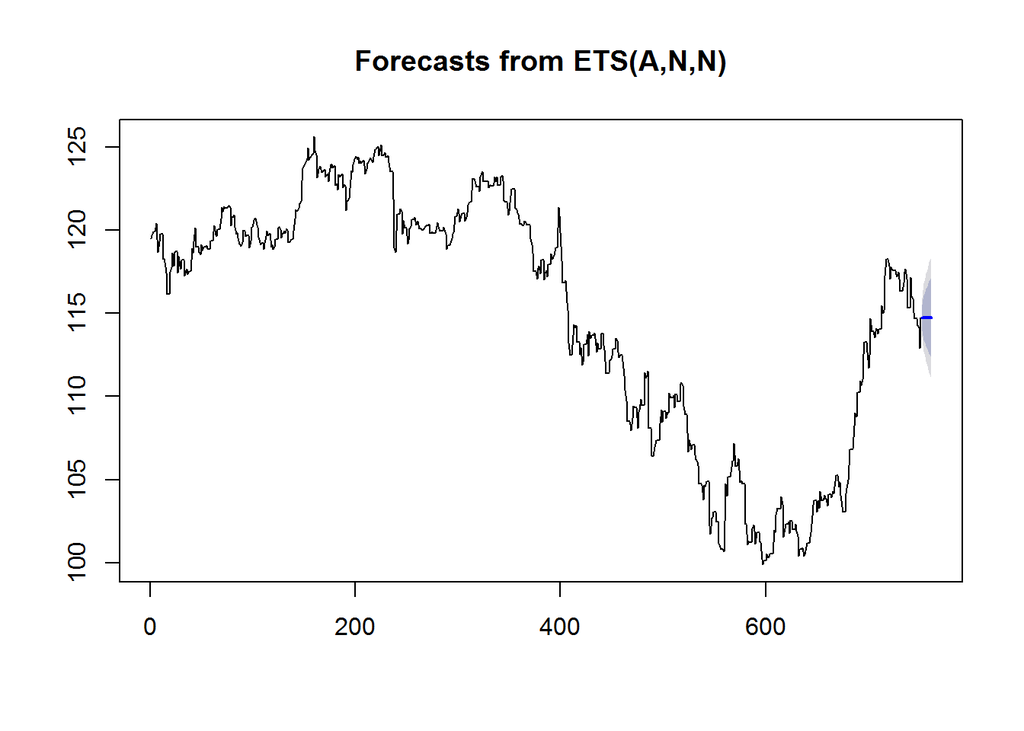

```r
## Plot the models
## opened price fit data
plot(forecast(ets(fit.op$Point.Forecast)))
```

```r
forecast(ets(fit.op$Point.Forecast), h = 4)
```

```
##     Point Forecast    Lo 80    Hi 80    Lo 95    Hi 95
## 752       114.7376 113.9701 115.5051 113.5639 115.9114
## 753       114.7376 113.6523 115.8230 113.0778 116.3975
## 754       114.7376 113.4084 116.0669 112.7047 116.7705
## 755       114.7376 113.2028 116.2725 112.3903 117.0850
```

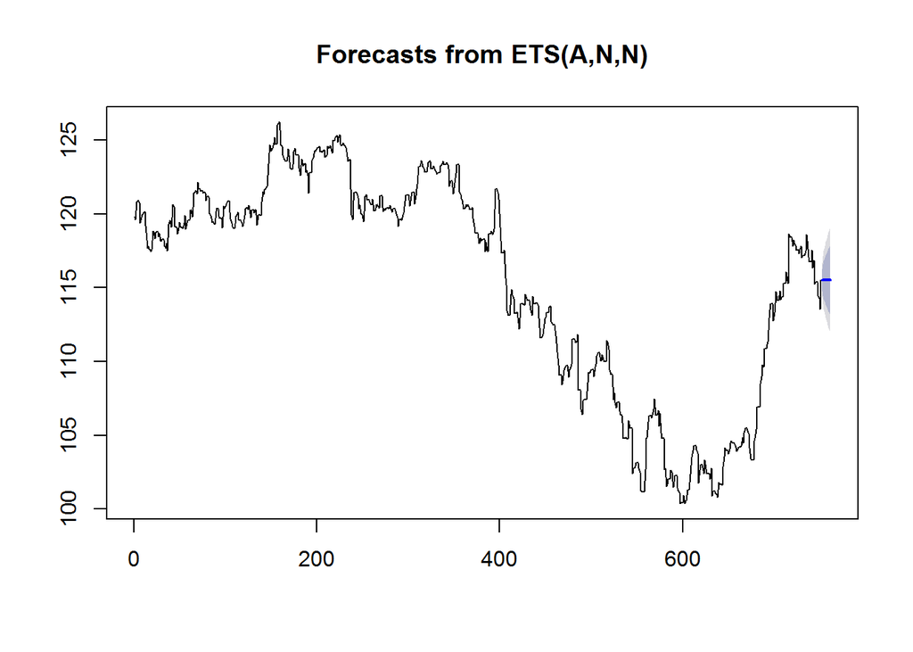

```r
## highest price fit data
plot(forecast(ets(fit.hi$Point.Forecast)))
```

```r
forecast(ets(fit.hi$Point.Forecast), h = 4)
```

```
##     Point Forecast    Lo 80    Hi 80    Lo 95    Hi 95
## 752       115.5206 114.7742 116.2670 114.3791 116.6621
## 753       115.5206 114.4651 116.5761 113.9063 117.1349
## 754       115.5206 114.2279 116.8133 113.5435 117.4977
## 755       115.5206 114.0279 117.0133 113.2377 117.8035
```

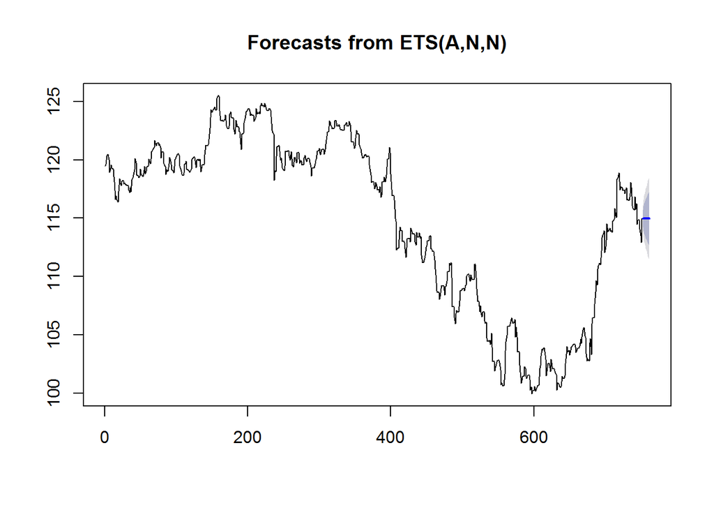

```r
## mean price fit data (mean price of daily highest and lowest price)
plot(forecast(ets(fit.mn$Point.Forecast)))
```

```r
forecast(ets(fit.mn$Point.Forecast), h = 4)
```

```
##     Point Forecast    Lo 80    Hi 80    Lo 95    Hi 95
## 752       114.9716 114.2285 115.7147 113.8352 116.1081
## 753       114.9716 113.9208 116.0224 113.3645 116.5787
## 754       114.9716 113.6846 116.2586 113.0033 116.9399
## 755       114.9716 113.4855 116.4577 112.6989 117.2443
```

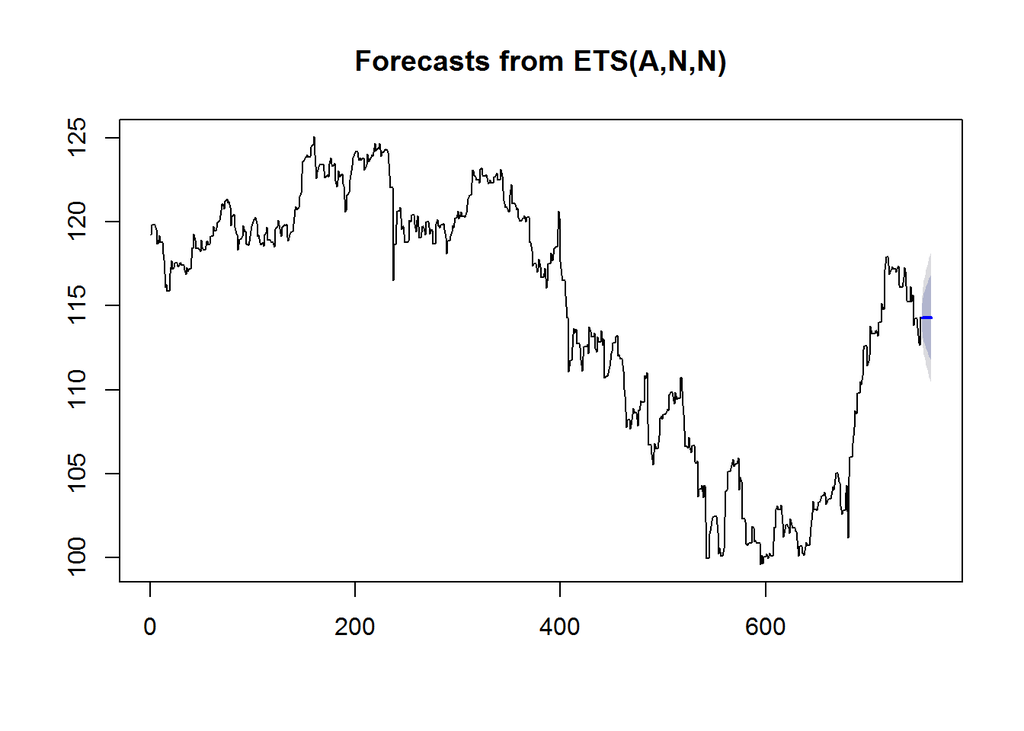

```r
## lowest price fit data
plot(forecast(ets(fit.lo$Point.Forecast)))
```

```r
forecast(ets(fit.lo$Point.Forecast), h = 4)
```

```
##     Point Forecast    Lo 80    Hi 80    Lo 95    Hi 95
## 752       114.3114 113.4671 115.1557 113.0202 115.6026
## 753       114.3114 113.1321 115.4907 112.5078 116.1149
## 754       114.3114 112.8731 115.7497 112.1118 116.5110
## 755       114.3114 112.6541 115.9686 111.7769 116.8459
```

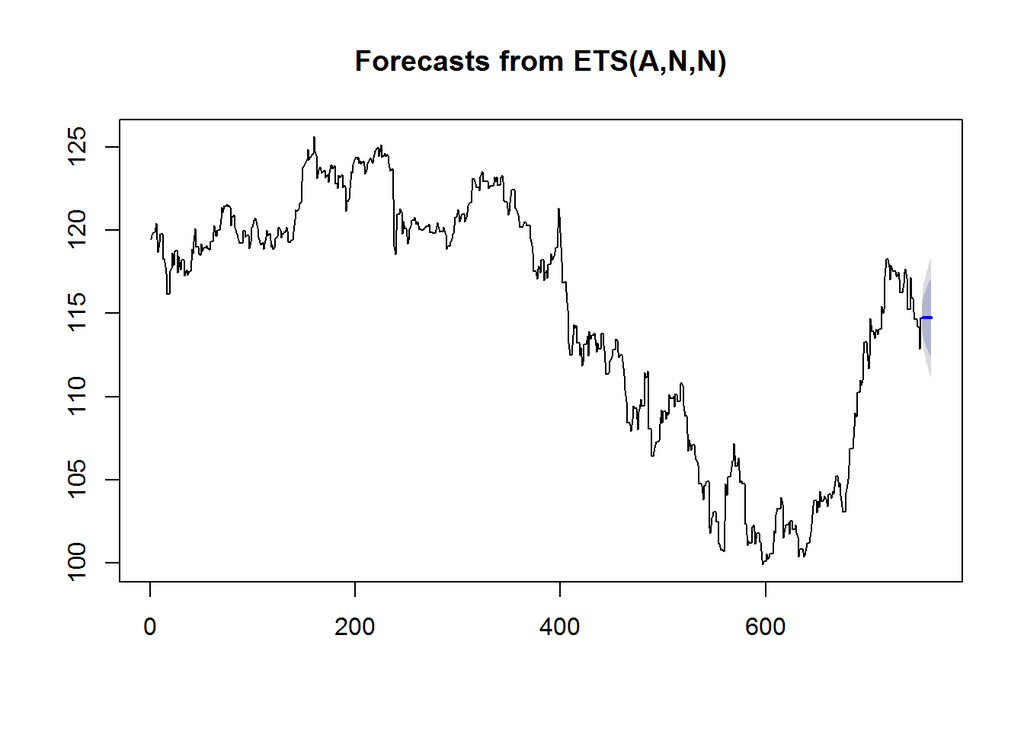

```r
## opened price fit data
plot(forecast(ets(fit.cl$Point.Forecast)))
```

```r
forecast(ets(fit.cl$Point.Forecast), h = 4)
```

```
##     Point Forecast    Lo 80    Hi 80    Lo 95    Hi 95
## 752       114.7616 113.9909 115.5323 113.5829 115.9403
## 753       114.7616 113.6718 115.8515 113.0948 116.4284
## 754       114.7616 113.4268 116.0964 112.7202 116.8030
## 755       114.7616 113.2204 116.3029 112.4045 117.1188
```

```r
fcdata <- do.call(cbind, list(USDJPY.FPOP = fit.op$Point.Forecast, USDJPY.FPHI = fit.hi$Point.Forecast, USDJPY.FPMN = fit.mn$Point.Forecast, USDJPY.FPLO = fit.lo$Point.Forecast, USDJPY.FPCL = fit.cl$Point.Forecast, USDJPY.Close = fit.op$USDJPY.Close))
fcdata <- na.omit(fcdata)
names(fcdata) <- c('USDJPY.FPOP', 'USDJPY.FPHI', 'USDJPY.FPMN', 'USDJPY.FPLO', 'USDJPY.FPCL', 'USDJPY.Close')
```

### 2.1.5 Staking Model

```r
simStakes <- function(mbase, prCat = 'Op', baseDate = ymd('2015-01-01'), .parallel = FALSE, setPrice = 'Cl', initialFundSize = 100) {
  #'@ source('./function/simPrice.R')

  ## forecast staking price.
  fit1 <- simPrice(mbase, prCat = prCat, baseDate = baseDate, .parallel = .parallel)
  fit1 <- data.frame(Date = index(fit1), coredata(fit1)) %>% tbl_df
  fit1 <- na.omit(fit1)

  ## forecast settlement price.
  fit2 <- simPrice(mbase, prCat = setPrice, baseDate = baseDate, .parallel = .parallel)
  fit2 <- data.frame(Date = index(fit2), coredata(fit2)) %>% tbl_df
  fit2 <- na.omit(fit2)

  ## merge dataset
  fitm <- cbind(fit1, forClose = fit2$Point.Forecast) %>% tbl_df

  ## convert to probability.
  fitm %<>% mutate(Prob = pnorm(Point.Forecast, mean = forClose, sd = sd(forClose)))

  ## staking model and bankroll management.
  ## need to refer to Niko Martinen's fund management formula to maximise the stakes and profit base on Kelly models.
  ## https://github.com/scibrokes/betting-strategy-and-model-validation/blob/master/references/Creating%20a%20Profitable%20Betting%20Strategy%20for%20Football%20by%20Using%20Statistical%20Modelling.pdf
  #.... dynamic staking model need to adjusted based on updated bankroll but not portion of fixed USD100 per bet.
  fitm %<>% mutate(
      Diff = round(forClose - USDJPY.Close, 2),
      Back = ifelse(forClose > USDJPY.Close, 1, 0),
      Lay = ifelse(forClose < USDJPY.Close, 1, 0)) %>%
    #'@ mutate(Return.Back = ifelse(Prob > 0.5, Diff * Back * stakes, 0),
    #'@        Return.Lay = ifelse(Prob < 0.5, -Diff * Lay * stakes, 0))
    mutate(f = 2 * Prob - 1, )

  return(fitm)
  }
```

```r
## Will need to mofify above function, fit the data convertion and also staking from all below `chunks` into the function simStakes() above.
df.op <- data.frame(Date = index(fit.op), coredata(fit.op)) %>% tbl_df
df.hi <- data.frame(Date = index(fit.hi), coredata(fit.hi)) %>% tbl_df
df.mn <- data.frame(Date = index(fit.mn), coredata(fit.mn)) %>% tbl_df
df.lo <- data.frame(Date = index(fit.lo), coredata(fit.lo)) %>% tbl_df
df.cl <- data.frame(Date = index(fit.cl), coredata(fit.cl)) %>% tbl_df

df.op <- na.omit(df.op)
df.hi <- na.omit(df.hi)
df.mn <- na.omit(df.mn)
df.lo <- na.omit(df.lo)
df.cl <- na.omit(df.cl)
```

```r
## Set the forecast closed price as our staking criteria.
df.op <- cbind(df.op, forClose = df.op$Point.Forecast) %>% tbl_df
df.hi <- cbind(df.hi, forClose = df.hi$Point.Forecast) %>% tbl_df
df.mn <- cbind(df.mn, forClose = df.mn$Point.Forecast) %>% tbl_df
df.lo <- cbind(df.lo, forClose = df.lo$Point.Forecast) %>% tbl_df
df.cl <- cbind(df.cl, forClose = df.cl$Point.Forecast) %>% tbl_df
```

Convert the probability based on closing price as the settled price. Here I try to set USD1 as the criteria (baseline) of daily sakes for every single match.

```r
## convert all forecast price into probability.

## forecast the opened price.
df.op %<>% mutate(Prob = pnorm(forClose, mean = USDJPY.Close, sd = sd(USDJPY.Close)),
                  stakes = 1)

## forecast the highest price.
df.hi %<>% mutate(Prob = pnorm(forClose, mean = USDJPY.Close, sd = sd(USDJPY.Close)),
                  stakes = 1)

## forecast the mean price.
df.mn %<>% mutate(Prob = pnorm(forClose, mean = USDJPY.Close, sd = sd(USDJPY.Close)),
                  stakes = 1)

## forecast the lowest price.
df.lo %<>% mutate(Prob = pnorm(forClose, mean = USDJPY.Close, sd = sd(USDJPY.Close)),
                  stakes = 1)

## forecast the closed price.
df.cl %<>% mutate(Prob = pnorm(Point.Forecast, mean = forClose, sd = sd(forClose)),
                  stakes = 1)
```

```r
## Kelly staking models.

## placed orders on the opened price.
df.op %<>% mutate(
      Diff = round(forClose - USDJPY.Close, 2),
      Back = ifelse(forClose > USDJPY.Close, 1, 0),
      Lay = ifelse(forClose < USDJPY.Close, 1, 0)) %>%
    mutate(Return.Back = ifelse(Prob > 0.5, Diff * Back * stakes, 0),
           Return.Lay = ifelse(Prob < 0.5, -Diff * Lay * stakes, 0))

## placed orders on  the highest price.
df.hi %<>% mutate(
      Diff = round(forClose - USDJPY.Close, 2),
      Back = ifelse(forClose > USDJPY.Close, 1, 0),
      Lay = ifelse(forClose < USDJPY.Close, 1, 0)) %>%
    mutate(Return.Back = ifelse(Prob > 0.5, Diff * Back * stakes, 0),
           Return.Lay = ifelse(Prob < 0.5, -Diff * Lay * stakes, 0))

## placed orders on  the mean price.
df.mn %<>% mutate(
      Diff = round(forClose - USDJPY.Close, 2),
      Back = ifelse(forClose > USDJPY.Close, 1, 0),
      Lay = ifelse(forClose < USDJPY.Close, 1, 0)) %>%
    mutate(Return.Back = ifelse(Prob > 0.5, Diff * Back * stakes, 0),
           Return.Lay = ifelse(Prob < 0.5, -Diff * Lay * stakes, 0))

## placed orders on  the lowest price.
df.lo %<>% mutate(
      Diff = round(forClose - USDJPY.Close, 2),
      Back = ifelse(forClose > USDJPY.Close, 1, 0),
      Lay = ifelse(forClose < USDJPY.Close, 1, 0)) %>%
    mutate(Return.Back = ifelse(Prob > 0.5, Diff * Back * stakes, 0),
           Return.Lay = ifelse(Prob < 0.5, -Diff * Lay * stakes, 0))

## placed orders on  the closed price.
df.cl %<>% mutate(
      Diff = round(forClose - USDJPY.Close, 2),
      Back = ifelse(forClose > USDJPY.Close, 1, 0),
      Lay = ifelse(forClose < USDJPY.Close, 1, 0)) %>%
    mutate(Return.Back = ifelse(Prob > 0.5, Diff * Back * stakes, 0),
           Return.Lay = ifelse(Prob < 0.5, -Diff * Lay * stakes, 0))
```

### 2.1.6 Return of Investment

Profit and Loss

```r
## Profit and Loss.
cbind(
  OP = df.op %>% dplyr::select(Return.Back, Return.Lay) %>% colSums %>% data.frame,
  HI = df.hi %>% dplyr::select(Return.Back, Return.Lay) %>% colSums %>% data.frame,
  MN = df.mn %>% dplyr::select(Return.Back, Return.Lay) %>% colSums %>% data.frame,
  LO = df.lo %>% dplyr::select(Return.Back, Return.Lay) %>% colSums %>% data.frame,
  CL = df.cl %>% dplyr::select(Return.Back, Return.Lay) %>% colSums %>% data.frame)
```

```
##                  .      .     .      . .
## Return.Back 153.00 259.15 95.24  17.85 0
## Return.Lay  135.08  18.88 93.78 253.37 0
```

### 2.1.7 Return of Investment Optimization

```r
## optimise the stakes.
#'@ log(balance + portion Kelly edge ratio)
```

## 2.2 Question 2

# 2.3 Question 3

# 3. Conclusion

# 4. Appendix

## 4.1 Documenting File Creation

It’s useful to record some information about how your file was created.

- File creation date: 2015-07-22
- File latest updated date: 2017-05-03
- R version 3.3.3 (2017-03-06)
- R version (short form): 3.3.3
- [**rmarkdown** package](https://github.com/rstudio/rmarkdown) version: 1.4
- [**tufte** package](https://github.com/rstudio/tufte) version: 0.2.2
- File version: 1.0.1
- Author Profile: [®γσ, Eng Lian Hu](https://beta.rstudioconnect.com/englianhu/ryo-eng/)
- GitHub: [Source Code](https://github.com/scibrokes/betting-strategy-and-model-validation)
- Additional session information

[1] “2017-05-03 23:51:01 JST”

| Category | session_info |
| --- | --- |
| version | R version 3.3.3 (2017-03-06) |
| system | x86_64, mingw32 |
| ui | RTerm |
| language | (EN) |
| collate | Japanese_Japan.932 |
| tz | Asia/Tokyo |
| date | 2017-05-03 |

| Category | Sys.info |
| --- | --- |
| sysname | Windows |
| release | 10 x64 |
| version | build 14393 |
| nodename | RSTUDIO-SCIBROK |
| machine | x86-64 |
| login | scibr |
| user | scibr |
| effective_user | scibr |

## 4.2 Reference

1. [Stock Market Forecasting Using LASSO Linear Regression Model](https://github.com/englianhu/binary.com-interview-question/blob/master/reference/Stock%20Market%20Forecasting%20Using%20LASSO%20Linear%20Regression%20Model.pdf)
2. [Using LASSO from lars (or glmnet) package in R for variable selection](http://stats.stackexchange.com/questions/58531/using-lasso-from-lars-or-glmnet-package-in-r-for-variable-selection?answertab=votes#tab-top)
3. Difference between glmnet() and cv.glmnet() in R?
4. [Testing Kelly Criterion and Optimal f in R](https://alphaism.wordpress.com/2012/04/13/testing-kelly-criterion-and-optimal-f-in-r)
5. [Portfolio Optimization and Monte Carlo Simulation](https://github.com/scibrokes/kelly-criterion/blob/master/references/Portfolio%20Optimization%20and%20Monte%20Carlo%20Simulation.pdf)
6. [Glmnet Vignette](https://web.stanford.edu/~hastie/glmnet/glmnet_alpha.html)
7. [lasso怎么用算法实现？](http://cos.name/cn/topic/101533/#post-418215)
8. [The Sparse Matrix and {glmnet}](http://amunategui.github.io/sparse-matrix-glmnet/)
9. [Regularization and Variable Selection via the Elastic Net](https://github.com/englianhu/binary.com-interview-question/blob/master/reference/Regularization%20and%20Variable%20Selection%20via%20the%20Elastic%20Net.pdf)
10. [LASSO, Ridge, and Elastic Net](http://www4.stat.ncsu.edu/~post/josh/LASSO_Ridge_Elastic_Net_-_Examples.html)
11. [热门数据挖掘模型应用入门（一）: LASSO回归](http://cos.name/2016/10/data-mining-1-lasso/)
12. [The Lasso Page](http://statweb.stanford.edu/~tibs/lasso.html)
13. [Call_Valuation.R](https://api.rpubs.com/Mariano/call)
14. [Lecture 6 – Stochastic Processes and Monte Carlo](http://zorro-trader.com/manual/en/Lecture%206.htm)
15. [The `caret` Package](http://topepo.github.io/caret/index.html)
16. [Time Series Cross Validation](https://rpubs.com/crossxwill/time-series-cv)
17. [Character-Code.com](http://character-code.com/)
18. [Size Matters – Kelly Optimization](https://alphaism.wordpress.com/2012/03/26/size-matters-kelly-optimization/)

**Powered by - Copyright® Intellectual Property Rights of [Scibrokes®](http://www.scibrokes.com)個人の経営企業**